# Taller Regresión Lineal Simple

Fernando Cabrera y Keisy Polo

23 de octubre de 2026

# Sección 7.4. Ejercicio 9

Variables:

- $x$: densidad (g/cm$^3$), variable explicativa.
- $y$: porcentaje de ceniza, variable respuesta.

Cargamos los datos

```r
x <- c(1.25, 1.325, 1.375, 1.45, 1.55)   # Densidad (g/cm^3)
y <- c(1.93, 4.63, 8.95, 15.05, 23.31)   # Porcentaje de ceniza
n <- length(x)

datos <- data.frame(Densidad = x, Ceniza = y)
kable(datos)
```

| Densidad | Ceniza |
| --- | --- |
| 1.250 | 1.93 |
| 1.325 | 4.63 |
| 1.375 | 8.95 |
| 1.450 | 15.05 |
| 1.550 | 23.31 |

## Inciso 1: Diagrama de dispersión y verificación del modelo lineal

Graficamos $y$ contra $x$. Si los puntos siguen aproximadamente una línea recta (sin curvatura marcada), un modelo lineal es razonable.

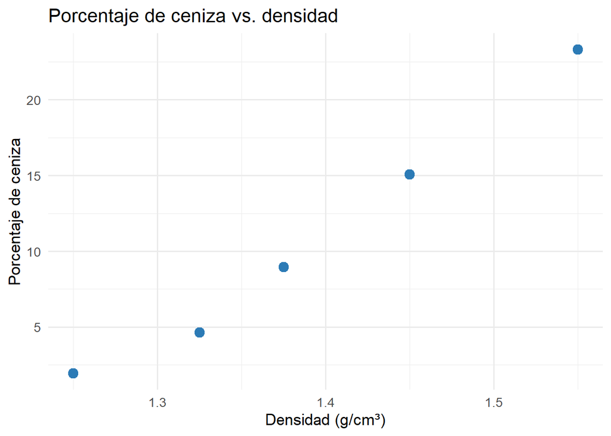

```r
ggplot(datos, aes(x = Densidad, y = Ceniza)) +
  geom_point(size = 3.5, color = "#2C7BB6") +
  labs(title = "Porcentaje de ceniza vs. densidad",
       x = "Densidad (g/cm³)", y = "Porcentaje de ceniza") +
  theme_minimal(base_size = 13)
```

El diagrama de dispersión muestra una relación positiva y aproximadamente lineal entre la densidad y el porcentaje de ceniza. Los puntos se alinean cerca de una recta y no se observan valores atípicos, por lo que un modelo lineal simple es adecuado.

## Inciso 2: Recta de mínimos cuadrados

El modelo es
$$y_i = \beta_0 + \beta_1 x_i + \varepsilon_i,$$
y la recta ajustada es $\hat{y} = \hat{\beta}_0 + \hat{\beta}_1 x$, con

$$\hat{\beta}_1 = \frac{\sum_{i=1}^{n} (x_i - \bar{x})(y_i -
\bar{y})}{\sum_{i=1}^{n} (x_i - \bar{x})^2},
\qquad
\hat{\beta}_0 = \bar{y} - \hat{\beta}_1 \bar{x}.$$

### Paso 1: Medias muestrales

```r
xbar <- mean(x)
ybar <- mean(y)
c(xbar = xbar, ybar = ybar)
```

```
##   xbar   ybar
##  1.390 10.774
```

### Paso 2: Sumas de cuadrados y productos cruzados

$$S_{xx} = \sum_{i=1}^{n} (x_i - \bar{x})^2, \qquad
S_{xy} = \sum_{i=1}^{n} (x_i - \bar{x})(y_i - \bar{y}), \qquad
S_{yy} = \sum_{i=1}^{n} (y_i - \bar{y})^2.$$

```r
Sxx <- sum((x - xbar)^2)
Sxy <- sum((x - xbar) * (y - ybar))
Syy <- sum((y - ybar)^2)
c(Sxx = Sxx, Sxy = Sxy, Syy = Syy)
```

```
##       Sxx       Sxy       Syy
##   0.05325   3.92720 294.72752
```

### Paso 3: Estimadores $\hat{\beta}_1$ y $\hat{\beta}_0$

```r
b1 <- Sxy / Sxx
b0 <- ybar - b1 * xbar
c(beta0_hat = b0, beta1_hat = b1)
```

```
## beta0_hat beta1_hat
## -91.73883  73.75023
```

La recta de mínimos cuadrados es

$$\hat{y} = -91.7388 + 73.7502 \,
x$$

### Verificación con `lm()`

```r
modelo <- lm(Ceniza ~ Densidad, data = datos)
summary(modelo)
```

```
##
## Call:
## lm(formula = Ceniza ~ Densidad, data = datos)
##
## Residuals:
##       1       2       3       4       5
##  1.4810 -1.3502 -0.7177 -0.1490  0.7360
##
## Coefficients:
##             Estimate Std. Error t value Pr(>|t|)
## (Intercept)  -91.739      7.872  -11.65  0.00136 **
## Densidad      73.750      5.648   13.06  0.00097 ***
## ---
## Signif. codes:  0 '***' 0.001 '**' 0.01 '*' 0.05 '.' 0.1 ' ' 1
##
## Residual standard error: 1.303 on 3 degrees of freedom
## Multiple R-squared:  0.9827, Adjusted R-squared:  0.9769
## F-statistic: 170.5 on 1 and 3 DF,  p-value: 0.0009699
```

Los coeficientes coinciden con los calculados a mano:

```r
kable(data.frame(
  Coeficiente = c("Intercepto", "Pendiente"),
  A_mano = c(b0, b1),
  lm = unname(coef(modelo))
), digits = 5)
```

| Coeficiente | A_mano | lm |
| --- | --- | --- |
| Intercepto | -91.73883 | -91.73883 |
| Pendiente | 73.75023 | 73.75023 |

## Inciso 3: Cambio en el porcentaje de ceniza si la densidad difiere en 0.1 g/cm³

La pendiente $\hat{\beta}_1$ indica el cambio en $\hat{y}$ por cada unidad de $x$. Si $\Delta x = 0.1$:

$$\Delta \hat{y} = \hat{\beta}_1 \, \Delta x = (73.7502)(0.1).$$

```r
delta_x <- 0.1
delta_y <- b1 * delta_x
delta_y
```

```
## [1] 7.375023
```

**Respuesta:** se predice que el porcentaje de ceniza difiera en aproximadamente 7.375 puntos porcentuales.

## Inciso 4: Pronóstico para $x = 1.40$ g/cm³

$$\hat{y}(1.40) = \hat{\beta}_0 + \hat{\beta}_1 (1.40).$$

```r
x0 <- 1.40
y0 <- b0 + b1 * x0
y0
```

```
## [1] 11.5115
```

```r
# Comprobación con predict
predict(modelo, newdata = data.frame(Densidad = x0))
```

```
##       1
## 11.5115
```

**Respuesta:** para partículas con densidad 1.40 g/cm$^3$ se pronostica un porcentaje de ceniza de aproximadamente 11.512.

Como $1.25 \le 1.40 \le 1.55$, el valor de $x$ está dentro del rango de los datos observados, por lo que el pronóstico es confiable.

## Inciso 5: Valores ajustados

Para cada observación $i = 1, \dots, 5$:
$$\hat{y}_i = \hat{\beta}_0 + \hat{\beta}_1 x_i .$$

```r
yhat <- b0 + b1 * x

tabla_ajuste <- data.frame(i = 1:n, x_i = x, y_i = y, yhat_i = yhat)
kable(tabla_ajuste, digits = 4,
      col.names = c("i", "$x_i$", "$y_i$", "$\\hat{y}_i$"),
      caption = "Valores ajustados")
```

Valores ajustados

| i | $x_i$ | $y_i$ | $\hat{y}_i$ |
| --- | --- | --- | --- |
| 1 | 1.250 | 1.93 | 0.4490 |
| 2 | 1.325 | 4.63 | 5.9802 |
| 3 | 1.375 | 8.95 | 9.6677 |
| 4 | 1.450 | 15.05 | 15.1990 |
| 5 | 1.550 | 23.31 | 22.5740 |

## Inciso 6: Residuos

El residuo de cada observación es
$$e_i = y_i - \hat{y}_i .$$

```r
e <- y - yhat

tabla_res <- data.frame(i = 1:n, x_i = x, y_i = y, yhat_i = yhat, e_i = e)
kable(tabla_res, digits = 4,
      col.names = c("i", "$x_i$", "$y_i$", "$\\hat{y}_i$", "$e_i$"),
      caption = "Residuos")
```

Residuos

| i | $x_i$ | $y_i$ | $\hat{y}_i$ | $e_i$ |
| --- | --- | --- | --- | --- |
| 1 | 1.250 | 1.93 | 0.4490 | 1.4810 |
| 2 | 1.325 | 4.63 | 5.9802 | -1.3502 |
| 3 | 1.375 | 8.95 | 9.6677 | -0.7177 |
| 4 | 1.450 | 15.05 | 15.1990 | -0.1490 |
| 5 | 1.550 | 23.31 | 22.5740 | 0.7360 |

Propiedad de verificación: con intercepto en el modelo, $\sum_{i=1}^{n} e_i = 0$.

```r
sum(e)
```

```
## [1] -4.862777e-14
```

En efecto, esta suma es aproximadamente 0.

### ¿Qué punto tiene el residuo de mayor magnitud?

```r
i_max <- which.max(abs(e))
cat("Punto i =", i_max,
    "\nDensidad x =", x[i_max],
    "\nCeniza observada y =", y[i_max],
    "\nCeniza ajustada yhat =", round(yhat[i_max], 4),
    "\nResiduo e =", round(e[i_max], 4))
```

```
## Punto i = 1
## Densidad x = 1.25
## Ceniza observada y = 1.93
## Ceniza ajustada yhat = 0.449
## Residuo e = 1.481
```

**Respuesta:** el residuo de mayor magnitud corresponde al punto con $x = 1.25$ (primer punto), con $e_{1} = 1.481$.

## Inciso 7: Correlación entre densidad y porcentaje de ceniza

$$r = \frac{S_{xy}}{\sqrt{S_{xx} \, S_{yy}}} .$$

```r
r <- Sxy / sqrt(Sxx * Syy)
r
```

```
## [1] 0.9913177
```

```r
# Comprobación con cor()
cor(x, y)
```

```
## [1] 0.9913177
```

**Respuesta:** $r = 0.9913$, una correlación lineal positiva muy fuerte, lo que respalda el uso del modelo lineal.

## Inciso 8: Sumas de cuadrados

Definimos:

$$\text{SCT} = \sum_{i=1}^{n} (y_i - \bar{y})^2, \qquad
\text{SCR} = \sum_{i=1}^{n} (\hat{y}_i - \bar{y})^2, \qquad
\text{SCE} = \sum_{i=1}^{n} (y_i - \hat{y}_i)^2 .$$

con la identidad $\text{SCT} = \text{SCR} + \text{SCE}$.

```r
SCT <- sum((y - ybar)^2)        # Suma total de cuadrados
SCR <- sum((yhat - ybar)^2)     # Suma de cuadrados de regresión
SCE <- sum((y - yhat)^2)        # Suma de cuadrados del error

kable(data.frame(
  Suma = c("SCR (regresión)", "SCE (error)", "SCT (total)"),
  Valor = c(SCR, SCE, SCT)
), digits = 4)
```

| Suma | Valor |
| --- | --- |
| SCR (regresión) | 289.6319 |
| SCE (error) | 5.0956 |
| SCT (total) | 294.7275 |

Verificamos la identidad $\text{SCT} = \text{SCR} + \text{SCE}$:

```r
c(SCR_mas_SCE = SCR + SCE, SCT = SCT)
```

```
## SCR_mas_SCE         SCT
##    294.7275    294.7275
```

```r
all.equal(SCT, SCR + SCE)
```

```
## [1] TRUE
```

## Inciso 9: Cociente $\text{SCR}/\text{SCT}$ y su relación con $r$

$$\frac{\text{SCR}}{\text{SCT}} = R^2 .$$

```r
R2 <- SCR / SCT
R2
```

```
## [1] 0.9827108
```

```r
# Comparación con r^2 y con el R^2 de lm()
c(SCR_SCT = R2, r_cuadrado = r^2, R2_lm = summary(modelo)$r.squared)
```

```
##    SCR_SCT r_cuadrado      R2_lm
##  0.9827108  0.9827108  0.9827108
```

# Sección 7.4. Ejercicio 10.

Variables:

- $x$: variable explicativa.
- $y$: variable respuesta.
- $z = \ln y$: transformación de $y$.

Cargamos los datos

```r
x10 <- 1:10
y10 <- c(0.2, 0.3, 0.5, 0.5, 1.3, 2.3, 2.9, 4.5, 8.7, 12.0)
z10 <- c(-1.61, -1.20, -0.69, -0.69, 0.26, 0.83, 1.06, 1.50, 2.16, 2.48)
n10 <- length(x10)

datos10 <- data.frame(x = x10, y = y10, z = z10)
kable(datos10, col.names = c("$x$", "$y$", "$z = \\ln y$"))
```

| $x$ | $y$ | $z = \ln y$ |
| --- | --- | --- |
| 1 | 0.2 | -1.61 |
| 2 | 0.3 | -1.20 |
| 3 | 0.5 | -0.69 |
| 4 | 0.5 | -0.69 |
| 5 | 1.3 | 0.26 |
| 6 | 2.3 | 0.83 |
| 7 | 2.9 | 1.06 |
| 8 | 4.5 | 1.50 |
| 9 | 8.7 | 2.16 |
| 10 | 12.0 | 2.48 |

## Inciso 1: Diagrama de dispersión de $(x, y)$

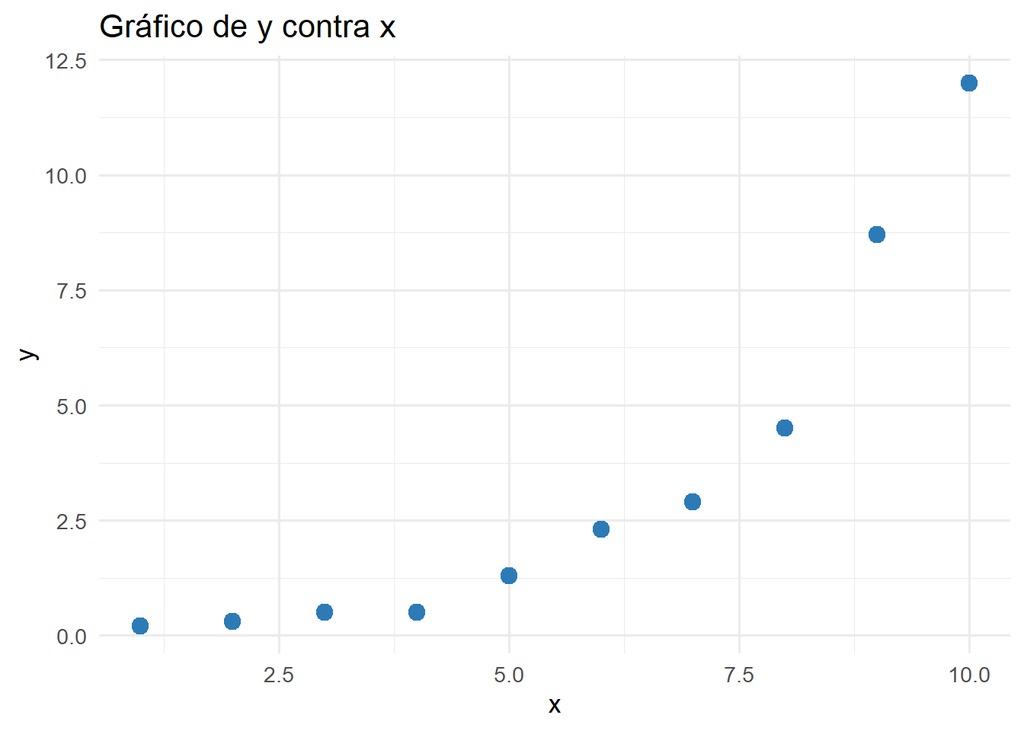

```r
ggplot(datos10, aes(x = x, y = y)) +
  geom_point(size = 3.5, color = "#2C7BB6") +
  labs(title = "Gráfico de y contra x",
       x = "x", y = "y") +
  theme_minimal(base_size = 13)
```

El diagrama de dispersión muestra que la relación entre $x$ y $y$ no es lineal: $y$ crece lentamente para valores pequeños de $x$ y cada vez más rápido para valores grandes, lo que describe una curva y no una recta.

## Inciso 2: ¿Se debe usar la recta de mínimos cuadrados para pronosticar $y$?

Para comprobarlo, ajustamos la recta de mínimos cuadrados a los puntos $(x, y)$ y la dibujamos sobre el diagrama.

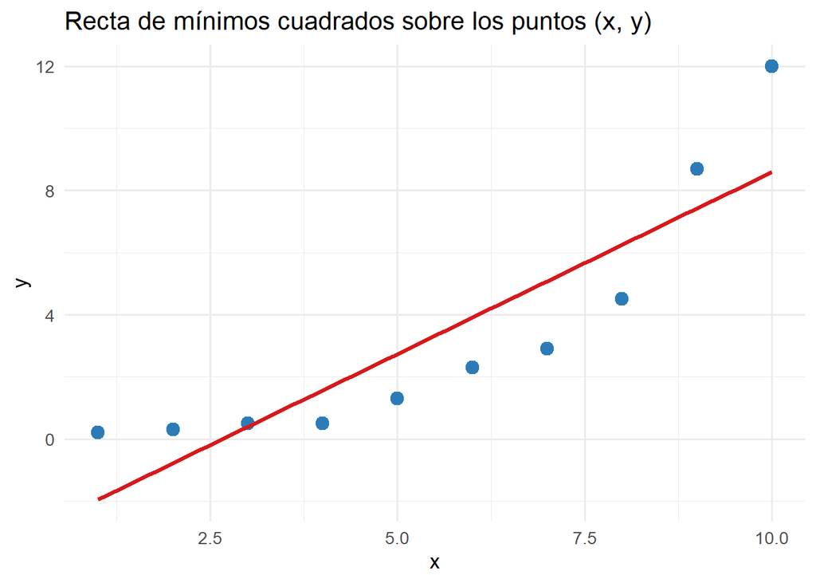

```r
modelo10 <- lm(y ~ x, data = datos10)

ggplot(datos10, aes(x = x, y = y)) +
  geom_point(size = 3.5, color = "#2C7BB6") +
  geom_smooth(method = "lm", se = FALSE, color = "#D7191C") +
  labs(title = "Recta de mínimos cuadrados sobre los puntos (x, y)",
       x = "x", y = "y") +
  theme_minimal(base_size = 13)
```

Revisamos también los residuos $e_i = y_i - \hat{y}_i$:

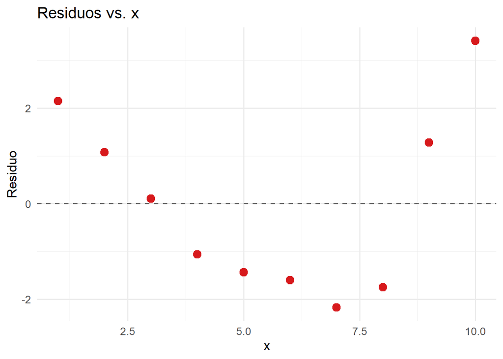

```r
e10 <- resid(modelo10)

ggplot(data.frame(x = x10, e = e10), aes(x = x, y = e)) +
  geom_hline(yintercept = 0, linetype = "dashed", color = "gray40") +
  geom_point(size = 3.5, color = "#D7191C") +
  labs(title = "Residuos vs. x", x = "x", y = "Residuo") +
  theme_minimal(base_size = 13)
```

**Respuesta:** No. El diagrama de dispersión muestra que la relación entre $x$ y $y$ no es lineal, sino una curva creciente. Al ajustar la recta de mínimos cuadrados, los residuos no se distribuyen al azar alrededor de cero, sino que siguen un patrón en forma de “U” (positivos, luego negativos y luego positivos). Esto indica que el modelo lineal no describe bien los datos, por lo que no es adecuado usar la recta para pronosticar $y$ cuando $x = 4.5$.

## Inciso 3: Diagrama de dispersión de $(x, z)$, con $z = \ln y$

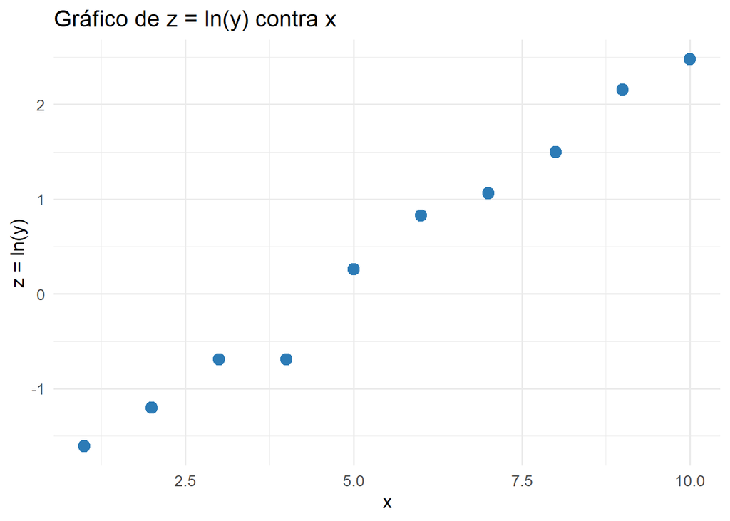

```r
ggplot(datos10, aes(x = x, y = z)) +
  geom_point(size = 3.5, color = "#2C7BB6") +
  labs(title = "Gráfico de z = ln(y) contra x",
       x = "x", y = "z = ln(y)") +
  theme_minimal(base_size = 13)
```

El diagrama de dispersión de $(x, z)$ muestra una relación aproximadamente lineal y creciente entre $x$ y $z = \ln y$. Al transformar $y$ con el logaritmo natural, la curvatura desaparece, por lo que un modelo lineal sí es adecuado para $z$.

## Inciso 4: Pronóstico de $z$ cuando $x = 4.5$

### Paso 1: Recta de mínimos cuadrados para $(x, z)$

El modelo es $z_i = \beta_0 + \beta_1 x_i + \varepsilon_i$ y la recta ajustada es $\hat{z} = \hat{\beta}_0 + \hat{\beta}_1 x$.

```r
modelo_z10 <- lm(z ~ x, data = datos10)
b0_z <- coef(modelo_z10)[1]
b1_z <- coef(modelo_z10)[2]
c(beta0_hat = unname(b0_z), beta1_hat = unname(b1_z))
```

```
##  beta0_hat  beta1_hat
## -2.1600000  0.4672727
```

$$\hat{z} = -2.1600 + 0.4673 \,
x$$

### Paso 2: Pronóstico en $x = 4.5$

$$\hat{z}(4.5) = \hat{\beta}_0 + \hat{\beta}_1 (4.5).$$

```r
x0_10 <- 4.5
z0 <- unname(b0_z + b1_z * x0_10)
z0
```

```
## [1] -0.05727273
```

```r
# Comprobación con predict
predict(modelo_z10, newdata = data.frame(x = x0_10))
```

```
##           1
## -0.05727273
```

### Paso 3: ¿Es un método adecuado?

Dibujamos la recta sobre los puntos y revisamos los residuos.

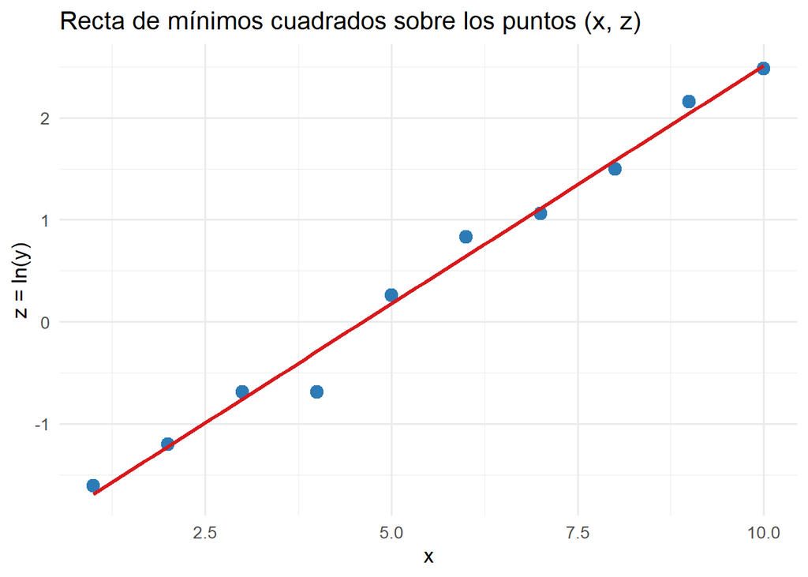

```r
ggplot(datos10, aes(x = x, y = z)) +
  geom_point(size = 3.5, color = "#2C7BB6") +
  geom_smooth(method = "lm", se = FALSE, color = "#D7191C") +
  labs(title = "Recta de mínimos cuadrados sobre los puntos (x, z)",
       x = "x", y = "z = ln(y)") +
  theme_minimal(base_size = 13)
```

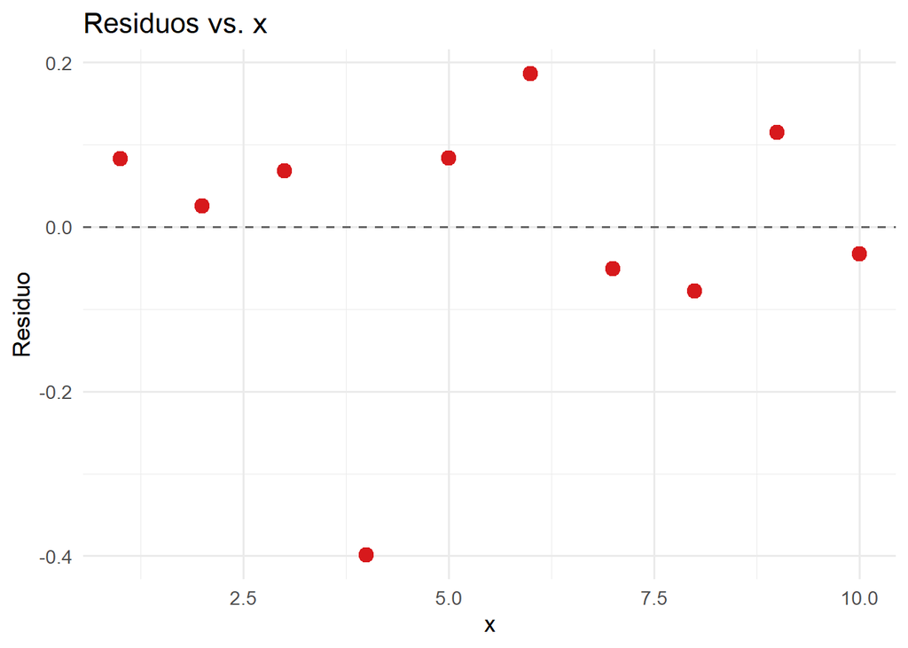

```r
e_z10 <- resid(modelo_z10)

ggplot(data.frame(x = x10, e = e_z10), aes(x = x, y = e)) +
  geom_hline(yintercept = 0, linetype = "dashed", color = "gray40") +
  geom_point(size = 3.5, color = "#D7191C") +
  labs(title = "Residuos vs. x", x = "x", y = "Residuo") +
  theme_minimal(base_size = 13)
```

Para medir qué tan bien se ajusta la recta, calculamos $R^2 = r^2$.

```r
cor(x10, z10)^2
```

```
## [1] 0.9870661
```

**Respuesta:** el valor pronosticado es $\hat{z}(4.5) \approx -0.0573$. Sí es un método adecuado: los puntos $(x, z)$ siguen una relación lineal, la recta se ajusta muy bien a los datos ($R^2 \approx 0.987$) y los residuos son pequeños y no muestran un patrón claro. Además, $x = 4.5$ está dentro del rango de los datos observados.

## Inciso 5: Pronóstico de $y$ a partir de $\hat{z}$

Sea $\hat{z}$ el valor pronosticado en el inciso 4. Definimos

$$\hat{y} = e^{\hat{z}} .$$

```r
y_hat0 <- exp(z0)
y_hat0
```

```
## [1] 0.9443365
```

Para comparar, ubicamos este valor sobre los puntos originales $(x, y)$ junto con el pronóstico de la recta del inciso 2:

```r
y_recta0 <- unname(predict(modelo10, newdata = data.frame(x = x0_10)))

kable(data.frame(
  Método = c("Recta sobre (x, y)", "exp(z-hat) con la recta sobre (x, z)"),
  Pronóstico = c(y_recta0, y_hat0)
), digits = 4)
```

| Método | Pronóstico |
| --- | --- |
| Recta sobre (x, y) | 2.1491 |
| exp(z-hat) con la recta sobre (x, z) | 0.9443 |

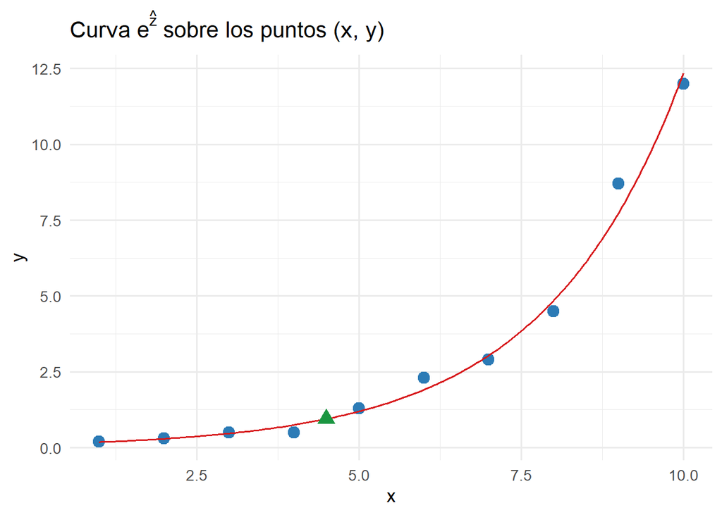

```r
curva <- data.frame(x = seq(1, 10, length.out = 200))
curva$y <- exp(b0_z + b1_z * curva$x)

ggplot(datos10, aes(x = x, y = y)) +
  geom_point(size = 3.5, color = "#2C7BB6") +
  geom_line(data = curva, aes(x = x, y = y), color = "#D7191C") +
  geom_point(aes(x = x0_10, y = y_hat0), color = "#1A9641", size = 4, shape = 17) +
  labs(title = expression("Curva " * e^hat(z) * " sobre los puntos (x, y)"),
       x = "x", y = "y") +
  theme_minimal(base_size = 13)
```

**Respuesta:** $\hat{y} = e^{\hat{z}} = e^{-0.0573} \approx 0.9443$. Es un pronosticador razonable porque $z = \ln y$ tiene una relación lineal con $x$, así que $y$ se comporta como una función exponencial de $x$, que es la curva que muestra el diagrama de $(x, y)$. Al aplicar la exponencial a $\hat{z}$ se regresa a la escala original de $y$, y el valor obtenido (0.9443) está entre los valores observados en $x = 4$ ($y = 0.5$) y $x = 5$ ($y = 1.3$), mientras que la recta sobre $(x, y)$ daba 2.1491, muy lejos de esos valores.